# Tarea 2 - Modelos Lineales Generalizados

[figure not shown]

Fecha de entrega: 6 de febrero 2024.

- Blanca E. García Manjarrez – 118886
- Mariano Villafuerte Gonzalez – 156057
- Thomas M. Rudolf - 169293
- Yuneri Pérez Arellano - 199813

## 1. Estimando una media Poisson usando una inicial discreta.

> Supongan que son dueños de una compañía de transporte con una flota grande de camiones. Las descomposturas ocurren aleatoriamente en el tiempo y supóngase que el número de descomposturas durante un intervalo de t días sigue un distribución Poisson con media $\lambda t$. El parámetro $\lambda$ es la tasa de descompostura diaria. Los posibles valores para $\lambda$ son 0.5, 1, 1.5, 2,2.5 y 3, con respectivas probabilidades 0.1, 0.2, 0.3, 0.2, 0.15 y 0.05. Si uno observa $y$ descomposturas, entonces la probabilidad posterior de $\lambda$ es proporcional a
> $$g(\lambda)exp(-t\lambda)(t\lambda)^y,$$
> donde $g$ es la distribución inicial.
> 1. Si 12 camiones se descomponen en un periodo de 6 días, encontrar la probabilidad posterior para las diferentes tasas.

```r
# Datos observados
y <- 12  # Número de descomposturas
t <- 6   # Número de días

# Parámetros y distribución inicial
v_lambda <- c(0.5, 1, 1.5, 2, 2.5, 3)
prob_inicial <- c(0.1, 0.2, 0.3, 0.2, 0.15, 0.05)

# Función de la distribución inicial
g <- function(lambda){
  prob_inicial[v_lambda == lambda]
}

# Función de la probabilidad posterior
dist_post <- function(lambda, y, t){
  g(lambda) * exp(-t * lambda) * (t * lambda)^y
}

# Calculamos la probabilidad posterior para cada valor de lambda
prob_post <- sapply(v_lambda, dist_post, y = y, t = t)

# Normalizamos las probabilidades para obtener la distribución posterior
prob_post <- prob_post / sum(prob_post)

# Imprimimos los resultados
resultados <- data.frame(lambda = v_lambda,prob_inicial = prob_inicial, prob_posterior = prob_post)
resultados |> gt() |> fmt_percent(columns = prob_inicial, decimals = 0) |> fmt_percent(columns = prob_posterior, decimals = 3)
```

| lambda | prob_inicial | prob_posterior |
| --- | --- | --- |
| 0.5 | 10% | 0.009% |
| 1.0 | 20% | 3.679% |
| 1.5 | 30% | 35.652% |
| 2.0 | 20% | 37.357% |
| 2.5 | 15% | 20.299% |
| 3.0 | 5% | 3.004% |

> 2. Encontrar la probabilidad de que no haya descomposturas durante la siguiente semana. Hint: Si la tasa es $\lambda$, la probabilidad condicional de no descomposturas durante un periodo de 7 días está dado por $exp(-7\lambda)$. Se puede calcular esta probabilidad predictiva multiplicando la lista de probabilidades condicionales por las probabilidades posteriores de $\lambda$ y encontrando la suma de los productos

```r
# Definir la función de probabilidad condicional para no descomposturas en 7 días
prob_nofalla <- function(lambda, t) {
  exp(-t * lambda) }

# Calcular la probabilidad predictiva multiplicando por las probabilidades posteriores y sumando
tabla_prob_pred <- resultados |>
  mutate(prob_pred = prob_posterior * prob_nofalla(v_lambda, 7)) |>
  summarise(prob_predt = sum(prob_pred)) |>
  gt() |> fmt_percent(columns = prob_predt, decimals = 3)

tabla_prob_pred
```

| prob_predt |
| --- |
| 0.005% |

## 2. Estimando una proporción y predicción de una muestra futura.

> Un estudio reporta sobre los efectos de largo plazo de exposición a bajas dosis de plomo en niños. Los investigadores analizaron el contenido de plomo en la caída de los dientes de leche. De los niños cuyos dientes tienen un contenido de plomo mayor que 22.22 ppm, 22 eventualmente se graduaron de la preparatoria y 7 no. Supongan que su densidad inicial para $p$, la proporción de todos tales niños que se graduaron de preparatoria es $beta(1, 1)$, y posterior es $beta(23, 8)$.
> 1. Encontrar un intervalo estimado de 90% para $p$.

```r
# Parámetros de la distribución Beta posterior
alpha_post <- 23
beta_post <- 8

# Percentiles de la distribución Beta para construir el intervalo
percentiles <- c(0.05, 0.95)

# Cuantiles de la distribución Beta
intervalo <- qbeta(percentiles, alpha_post, beta_post)

# Imprimir el resultado
data.frame(inf_05 = intervalo[1],
           sup_95 = intervalo[2]) |> gt() |> fmt_number(decimals = 2)
```

| inf_05 | sup_95 |
| --- | --- |
| 0.61 | 0.86 |

> 2. Encontrar la probabilidad de que $p$ exceda 0.6.

```r
# Parámetros de la distribución Beta posterior
alpha_post <- 23
beta_post <- 8

# Probabilidad de que p exceda 0.6
p <- 1 - pbeta(0.6, alpha_post, beta_post)

data.frame(p_exc60 = p) |> gt() |> fmt_percent(decimals = 2)
```

| p_exc60 |
| --- |
| 95.65% |

## 3. Estimando una media normal posterior con una inicial discreta.

> Supongamos que están interesados en estimar el promedio de caida de lluvia por año $\mu$ en (cm) para una ciudad grande del Centro de México. Supongan que la caída anual individual $y_1, . . . , y_n$ son obtenidas de una población que se supone $N(\mu, 100)$. Antes de recolectar los datos, supongan que creen que la lluvia media puede estar en los siguiente valores con respectivas probabilidades

| $\mu$ | 20 | 30 | 40 | 50 | 60 | 70 |
| --- | --- | --- | --- | --- | --- | --- |
| $g(\mu)$ | 0.1 | 0.15 | 0.25 | 0.25 | 0.15 | 0.1 |

> 1. Supongan que se observan los totales de caída de lluvia 38.6, 42.4, 57.5, 40.5, 51.7, 67.1, 33.4, 60.9, 64.1, 40.1, 40.7 y 6.4. Calcular la media.

> Para calcular la media posterior en este escenario, utilizaremos el enfoque bayesiano y la distribución normal conjugada. La distribución inicial es discreta y se da como $g(\mu)$, y la verosimilitud es la distribución normal $N(\mu,100)$.El código en R para calcular la media posterior después de observar los datos proporcionados sería el siguiente:

```r
# Datos observados
datos <- c(38.6, 42.4, 57.5, 40.5, 51.7, 67.1, 33.4, 60.9, 64.1, 40.1, 40.7, 6.4)

# Parámetros de la distribución inicial
v_mu <- c(20, 30, 40, 50, 60, 70)
prob_inicial <- c(0.1, 0.15, 0.25, 0.25, 0.15, 0.1)

# Número de observaciones
n <- length(datos)

# Actualizar la distribución inicial con los datos observados
for (i in 1:length(v_mu)) {
  prob_inicial[i] <- prob_inicial[i] * prod(dnorm(datos, mean = v_mu[i], sd = 10))
}

# Normalizar las probabilidades
prob_inicial <- prob_inicial / sum(prob_inicial)

# Calcular la media posterior
media_post <- sum(prob_inicial * v_mu)

data.frame(media = media_post) |> gt() |> fmt_number(decimals = 2)
```

| media |
| --- |
| 45.84 |

> 2. Calcular la función de verosimilitud utilizando como estadística suficiente la media $\bar{y}$.
> - Calcular las probabilidades posteriores para $\mu$
> - Encontrar un intervalo de probabilidad de 80% para $\mu$.

```r
# Datos observados
datos <- c(38.6, 42.4, 57.5, 40.5, 51.7, 67.1, 33.4, 60.9, 64.1, 40.1, 40.7, 6.4)

# Distribución a priori
v_mu <- c(20, 30, 40, 50, 60, 70)
g_mu <- c(0.1, 0.15, 0.25, 0.25, 0.15, 0.1)

# Parámetros de la distribución normal
desv_est <- 10
media_m <- mean(datos)

# Calculamos la función de verosimilitud
verosimilitud <- dnorm(media_m, mean = v_mu, sd = desv_est)

# Calculamos la distribución a posteriori
p_post <- g_mu * verosimilitud
p_post <- p_post / sum(p_post)

# Calculamos el intervalo de probabilidad del 80%
cumulative_prob <- cumsum(p_post)
lower_quantile <- min(v_mu[cumulative_prob >= 0.1])
upper_quantile <- max(v_mu[cumulative_prob <= 0.9])

intervalo_80 <- c(lower_quantile, upper_quantile)

res3 <- data.frame(mu = v_mu, verosimilitud = verosimilitud, posterior = p_post)
res3 |> gt()
```

| mu | verosimilitud | posterior |
| --- | --- | --- |
| 20 | 0.001632311 | 0.007475065 |
| 30 | 0.012407862 | 0.085231515 |
| 40 | 0.034697360 | 0.397235861 |
| 50 | 0.035694511 | 0.408651840 |
| 60 | 0.013508651 | 0.092793005 |
| 70 | 0.001880737 | 0.008612714 |

```r
int_80 <- data.frame(inf_80 = lower_quantile,sup_80 = upper_quantile)
int_80 |> gt()
```

| inf_80 | sup_80 |
| --- | --- |
| 40 | 50 |

## 4. Modelo muestral Cauchy.

> Supongan que se observa una muestra aleatoria $y_1, ... , y_n$ de una densidad Cauchy con parámetro de localización $theta$ y parámetro de escala 1. Si una inicial uniforme se considera para $theta$, entonces la densidad posterior, ¿cuál es? Supongan que se observan los datos 0,10,9,8,11,3,3,8,8,11. a. Calcula un grid para $theta$ de -2 a 12 en pasos de 0.1

```r
# Datos observados
datos <- c(0, 10, 9, 8, 11, 3, 3, 8, 8, 11)

# Definir el grid para theta
theta_grid <- seq(-2, 12, by = 0.1)
theta_grid
```

```
##   [1] -2.0 -1.9 -1.8 -1.7 -1.6 -1.5 -1.4 -1.3 -1.2 -1.1 -1.0 -0.9 -0.8 -0.7 -0.6
##  [16] -0.5 -0.4 -0.3 -0.2 -0.1  0.0  0.1  0.2  0.3  0.4  0.5  0.6  0.7  0.8  0.9
##  [31]  1.0  1.1  1.2  1.3  1.4  1.5  1.6  1.7  1.8  1.9  2.0  2.1  2.2  2.3  2.4
##  [46]  2.5  2.6  2.7  2.8  2.9  3.0  3.1  3.2  3.3  3.4  3.5  3.6  3.7  3.8  3.9
##  [61]  4.0  4.1  4.2  4.3  4.4  4.5  4.6  4.7  4.8  4.9  5.0  5.1  5.2  5.3  5.4
##  [76]  5.5  5.6  5.7  5.8  5.9  6.0  6.1  6.2  6.3  6.4  6.5  6.6  6.7  6.8  6.9
##  [91]  7.0  7.1  7.2  7.3  7.4  7.5  7.6  7.7  7.8  7.9  8.0  8.1  8.2  8.3  8.4
## [106]  8.5  8.6  8.7  8.8  8.9  9.0  9.1  9.2  9.3  9.4  9.5  9.6  9.7  9.8  9.9
## [121] 10.0 10.1 10.2 10.3 10.4 10.5 10.6 10.7 10.8 10.9 11.0 11.1 11.2 11.3 11.4
## [136] 11.5 11.6 11.7 11.8 11.9 12.0
```

> 2. Calcula la densidad posterior en este grid.

```r
# Datos observados
datos <- c(0, 10, 9, 8, 11, 3, 3, 8, 8, 11)

# Definir el grid para theta
theta_grid <- seq(-2, 12, by = 0.1)

# Función de densidad de la distribución Cauchy
densidad_cauchy <- function(theta, datos) {
  veros <- prod(1 / (pi * (1 + (datos - theta)^2)))
  prior <- 1 / (12 - (-2))  # Densidad a priori constante en el intervalo [-2, 12]
  posterior <- veros * prior
  return(posterior)
}

# Calcular la densidad posterior en el grid
d_posterior <- sapply(theta_grid, function(theta) densidad_cauchy(theta, datos))

# Normalizar la densidad posterior para que sume 1
d_posterior <- d_posterior / sum(d_posterior)

# Mostrar el resultado
res4b <- data.frame(theta = theta_grid, densidad_post = d_posterior)
res4b |> gt()
```

| theta | densidad_post |
| --- | --- |
| -2.0 | 1.126701e-12 |
| -1.9 | 1.496731e-12 |
| -1.8 | 1.998369e-12 |
| -1.7 | 2.681960e-12 |
| -1.6 | 3.618341e-12 |
| -1.5 | 4.907571e-12 |
| -1.4 | 6.691425e-12 |
| -1.3 | 9.171224e-12 |
| -1.2 | 1.263306e-11 |
| -1.1 | 1.748306e-11 |
| -1.0 | 2.429564e-11 |
| -0.9 | 3.387761e-11 |
| -0.8 | 4.734937e-11 |
| -0.7 | 6.624058e-11 |
| -0.6 | 9.259000e-11 |
| -0.5 | 1.290277e-10 |
| -0.4 | 1.788063e-10 |
| -0.3 | 2.457439e-10 |
| -0.2 | 3.340655e-10 |
| -0.1 | 4.481838e-10 |
| 0.0 | 5.925432e-10 |
| 0.1 | 7.716980e-10 |
| 0.2 | 9.907641e-10 |
| 0.3 | 1.256265e-09 |
| 0.4 | 1.577282e-09 |
| 0.5 | 1.966808e-09 |
| 0.6 | 2.443283e-09 |
| 0.7 | 3.032471e-09 |
| 0.8 | 3.769918e-09 |
| 0.9 | 4.704408e-09 |

[output cut: 111 more lines]

> 3. Grafica la densidad y comenten sobre sus características principales.

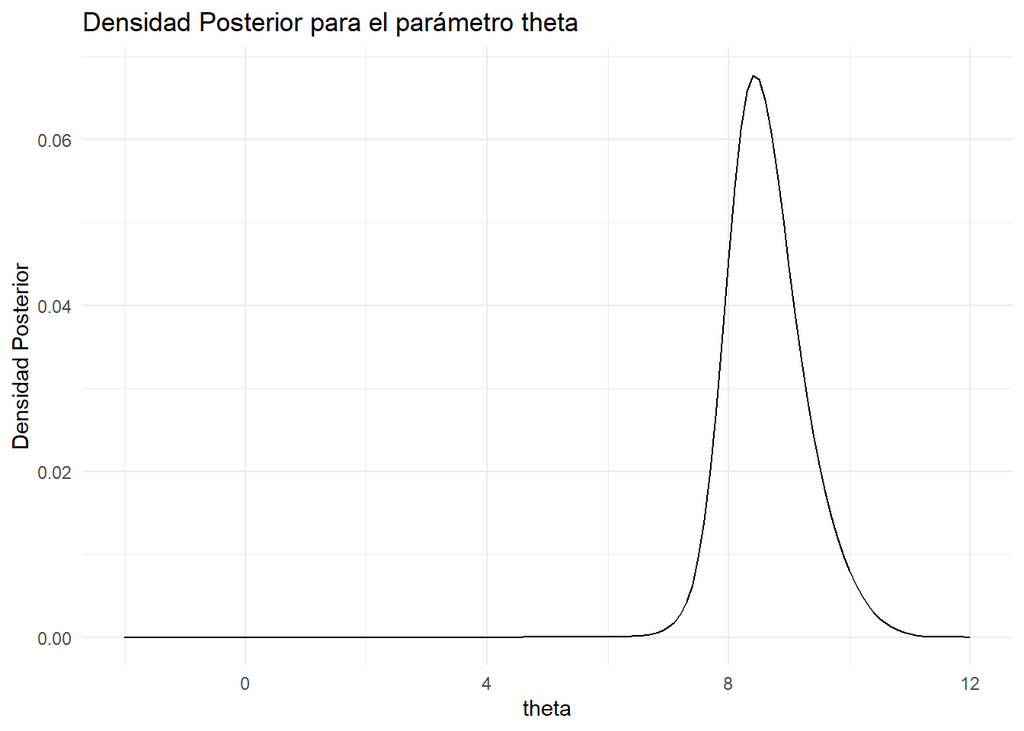

```r
# Crear el gráfico de densidad posterior
ggplot(res4b, aes(x = theta, y = d_posterior)) +
  geom_line() +
  labs(title = "Densidad Posterior para el parámetro theta",
       x = "theta",
       y = "Densidad Posterior") +
  theme_minimal()
```

> 4. Calcula la media posterior y desviación estándar posterior.

```r
res4d <- res4b |> summarise(media_post = sum(theta_grid * d_posterior),
            desv_est_post = sqrt(sum((theta_grid - media_post)^2 * d_posterior)))

res4d |> gt() |> fmt_number(decimals = 8)
```

| media_post | desv_est_post |
| --- | --- |
| 8.62934108 | 0.64537983 |

## 5. Robustez Bayesiana

> Supongan que están a punto de lanzar una moneda que creen que es honesta. Si p denota la probabilidad de obtener sol, entonces su mejor creencia es que $p = 0.5$. Adicionalmente, creen que es altamente probable que la moneda sea cercana a honesta, lo que cuantifican como $P(0.44 ≤ p ≤ 0.56) = 0.9$. Consideren las siguientes dos iniciales para p:
> $$P1 p ∼
> beta(100, 100)$$
> $$P2 p ∼ 0.9beta(500,
> 500) + 0.1beta(1, 1)$$
> 1. Simular 1000 valores de cada densidad inicial P1 y P2. Resumiendo las muestras simuladas, mostrar que ambas iniciales concuerdan con las creencias iniciales acerca de la probabilidad $p$ del lanzamiento de moneda.

```r
# Simular 1000 valores de P1
set.seed(123)  # Para reproducibilidad
p1_sim <- rbeta(1000, 100, 100)

# Simular 1000 valores de P2
set.seed(123)  # Para reproducibilidad
p2_sim <- 0.9 * rbeta(1000, 500, 500) + 0.1 * rbeta(1000, 1, 1)

est_p1 <- data.frame(
  media = mean(p1_sim),
  desv_est = sd(p1_sim),
  varianza = var(p1_sim)) |> gt() |>
  tab_header(
    title = "Estadisticas de P1",
    subtitle = "Beta(100,100)") |> fmt_number(decimals = 4)
est_p1
```

Estadisticas de P1

Beta(100,100)

| media | desv_est | varianza |
| --- | --- | --- |
| 0.5015 | 0.0346 | 0.0012 |

```r
est_p2 <- data.frame(
  media = mean(p2_sim),
  desv_est = sd(p2_sim),
  varianza = var(p2_sim)) |> gt() |>
  tab_header(
    title = "Estadisticas de P2",
    subtitle = "0.9Beta(500, 500) + 0.1Beta(1, 1)") |> fmt_number(decimals = 4)
est_p2
```

Estadisticas de P2

0.9Beta(500, 500) + 0.1Beta(1, 1)

| media | desv_est | varianza |
| --- | --- | --- |
| 0.4999 | 0.0322 | 0.0010 |

> *Podemos observar que ambas distribuciones iniciales (P1 y P2) concuerdan* *con las creencias iniciales de que la probabilidad* $p=0.5$
> 2. Supongan que lanzan la moneda 100 veces y obtienen 45 soles. Simular 1000 valores de las distribuciones posteriores P1 y P2, y calcular intervalos de probabilidad del 90 %.

```r
# Datos observados
lanza <- 100
sol_obs <- 45

# Simular 1000 valores de la distribución posterior P1
set.seed(123)
p1_post <- rbeta(1000, 100 + sol_obs, 100 + lanza - sol_obs)

# Simular 1000 valores de la distribución posterior P2
set.seed(123)
p2_post <- 0.9 * rbeta(1000, 500 + sol_obs, 500 + lanza - sol_obs) +
                 0.1 * rbeta(1000, 1 + sol_obs, 1 + lanza - sol_obs)

# Calcular intervalos de probabilidad del 90%
int_90_p1 <- quantile(p1_post, c(0.05, 0.95))
int_90_p2 <- quantile(p2_post, c(0.05, 0.95))

inter_90 <- data.frame(inf_p1 = int_90_p1[1],
                       sup_p1 = int_90_p1[2],
                       inf_p2 = int_90_p2[1],
                       sup_p2 = int_90_p2[2]) |> gt() |>
  tab_header(
    title = "Intervalos de P1 y P2",
    subtitle = "Considerando 45 soles") |> fmt_number(decimals = 4)

inter_90
```

Intervalos de P1 y P2

Considerando 45 soles

| inf_p1 | sup_p1 | inf_p2 | sup_p2 |
| --- | --- | --- | --- |
| 0.4397 | 0.5317 | 0.4686 | 0.5152 |

> 3. Supongan que sólo observan 30 soles de los 100 lanzamientos. Nuevamente simular 1000 valores de las dos posteriores y calcular intervalos de probabilidad del 90 %.

```r
# Datos observados
lanza <- 100
sol_obs <- 30

# Simular 1000 valores de la distribución posterior P1
set.seed(123)
cp1_post <- rbeta(1000, 100 + sol_obs, 100 + lanza - sol_obs)

# Simular 1000 valores de la distribución posterior P2
set.seed(123)
cp2_post <- 0.9 * rbeta(1000, 500 + sol_obs, 500 + lanza - sol_obs) +
                 0.1 * rbeta(1000, 1 + sol_obs, 1 + lanza - sol_obs)

# Calcular intervalos de probabilidad del 90%
cint_90_p1 <- quantile(cp1_post, c(0.05, 0.95))
cint_90_p2 <- quantile(cp2_post, c(0.05, 0.95))

cinter_90 <- data.frame(inf_p1 = cint_90_p1[1],
                       sup_p1 = cint_90_p1[2],
                       inf_p2 = cint_90_p2[1],
                       sup_p2 = cint_90_p2[2]) |> gt() |>
  tab_header(
    title = "Intervalos de P1 y P2",
    subtitle = "Considerando 30 soles") |> fmt_number(decimals = 4)

cinter_90
```

Intervalos de P1 y P2

Considerando 30 soles

| inf_p1 | sup_p1 | inf_p2 | sup_p2 |
| --- | --- | --- | --- |
| 0.3903 | 0.4817 | 0.4426 | 0.4871 |

> 4. Viendo los resultados de (b) y (c), comentar sobre la robustez de la inferencia con respecto a la elección de la densidad inicial en cada caso.

## 6. Aprendiendo de datos agrupados.

> Supongan que manejan en carretera y típicamente manejan a una velocidad constante de 70 km/h. Un día, rebasan un carro y son rebasados por 17 carros. Supongan que las velocidades son distribuídas $N(\mu, 100)$. Si rebasan s carros y son rebasados por f,
> 1. ¿Cuál es la verosimilitud de $\mu$?

```r
# Verosimilitud de mu
verosimilitud <- function(mu, s, f, vel) {
  likelihood <- (1 / sqrt(2 * pi * 100)) ^ (s + f) *
    exp(-(sum((rep(vel, s + f) - mu)^2) / 200))
  return(likelihood)
}

# Log-verosimilitud de mu
log_verosimilitud <- function(mu, s, f, vel) {
  log_likelihood <- -((s + f) / 2) * log(2 * pi * 100) -
    (sum((rep(vel, s + f) - mu)^2) / 200)
  return(log_likelihood)
}
```

> 2. Asignando una densidad inicial plana para $\mu$, si s = 1 y f = 17, graficar la densidad posterior de $\mu$.

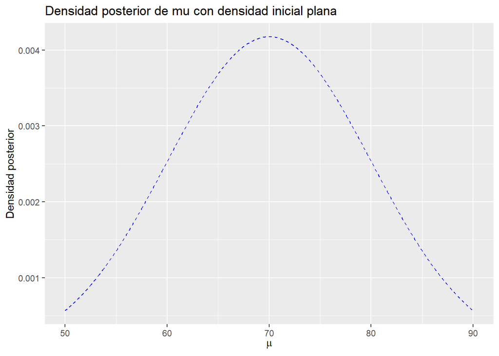

```r
# Datos
s <- 1  # Número de veces que rebasaron
f <- 17  # Número de veces que fueron rebasados
# Velocidad constante asumida (70 km/h)
vel <- 70

# Rango para la densidad a priori de mu
v_mu <- seq(50, 90, by = 0.1)

# Densidad a priori plana (constante en el rango)
prior_mu <- rep(1, length(v_mu))

# Verosimilitud
verosimilitud <- dnorm(rep(vel, s + f), mean = v_mu, sd = 10)

# Densidad a posteriori sin normalizar
post_norm <- verosimilitud * prior_mu

# Normalizar la densidad a posteriori
post <- post_norm / sum(post_norm)

# Graficar densidad a posteriori
df <- data.frame(mu = v_mu, posterior = post)

ggplot(df, aes(x = mu, y = posterior)) +
  geom_line(color = "blue", linetype = "dashed") +
  labs(x = expression(mu), y = "Densidad posterior",
       title = "Densidad posterior de mu con densidad inicial plana")
```

> 2. Usando la densidad encontrada en (a), encontrar la media posterior de $\mu$.

```r
# Calcular la media posterior de mu
media_post <- sum(v_mu * post)

data.frame(media_post) |> gt()
```

| media_post |
| --- |
| 70 |

> 3. Encontrar la probabilidad de que la velocidad promedio de los carros exceda 80 km/h.

```r
prob80 <- 1 - pnorm(80, mean = media_post, sd = 10)

data.frame(Prob_exceder_80 = prob80) |> gt() |> fmt_percent(decimals = 2)
```

| Prob_exceder_80 |
| --- |
| 15.87% |

## 7. Problema de Behrens-Fisher.

> Supongan que se observan dos muestras normales independientes, la primera se distribuye de acuerdo a una $N(\mu_1,\sigma^2_1)$ y la segunda de acuerdo a $N(\mu_2,\sigma^2_2)$.Denoten la primera muestra por $x_1,...,x_m$ y la segunda muestra por $y_1,...,y_n.$ Supongan también que los parámetros
> $$\theta
> = (\mu_1,\sigma^2_1,\mu_2,\sigma^2_2)$$
> tienen la distribución inicial vaga dada por:
> $$g(\theta)\propto\frac{1}{\sigma_1^2\sigma_2^2}$$
> 1. Encontrar la densidad posterior. Mostrar que los vectores $(\mu_1,\sigma_1^2)$ y $(\mu_2,\sigma_2^2)$ tienen distribuciones posteriores independientes.

> Para encontrar la densidad posterior, primero necesitamos establecer las distribuciones a priori y las verosimilitudes. Dado que se nos dice que los parámetros tienen una distribución inicial vaga proporcional a
> $$\frac{1}{\sigma_1^2\sigma_2^2}$$
> podemos expresar la densidad a priori conjunta como:
> $$g(\mu_1,\sigma_1^2,\mu_2,\sigma_2^2)\propto\frac{1}{\sigma_1^2\sigma_2^2}$$
> Ahora, la verosimilitud de las muestras $x$ y $y$, dado los parámetros $(\mu_1,\sigma_1^2,\mu_2,\sigma_2^2)$, se pueden expresar como el producto de las verosimilitudes para las dos muestras, ya que son independientes y cada una sigue una distribución normal:
> $$L(x_1,...,x_m,y_1,...,y_n|\mu_1,\sigma_1^2,\mu_2,\sigma_2^2)
> =$$
> $$L(x_1,...,x_m|\mu_1,\sigma_1^2)*L(y_1,...,y_n|\mu_2,\sigma_2^2)$$
> $$=(\frac{1}{\sqrt{2\pi\sigma_1}})^m*exp(-\frac{1}{2\sigma_1^2}*\sum_{i=1}^{m}(x_i-\mu_1)^2)*$$
> $$(\frac{1}{\sqrt{2\pi\sigma_2}})^n*exp(-\frac{1}{2\sigma_2^2}*\sum_{i=1}^{n}(y_i-\mu_2)^2)$$
> Multiplicando la densidad a priori por la verosimilitud, obtenemos la densidad posterior proporcional a:
> $$g(\mu_1,\sigma_1^2,\mu_2,\sigma_2^2|x_1,...,x_m,y_1,...,y_n)\propto\frac{1}{\sigma_1^2\sigma_2^2}*$$
> $$(\frac{1}{\sqrt{2\pi\sigma_1}})^m*exp(-\frac{1}{2\sigma_1^2}*\sum_{i=1}^{m}(x_i-\mu_1)^2)*$$
> $$(\frac{1}{\sqrt{2\pi\sigma_2}})^n*exp(-\frac{1}{2\sigma_2^2}*\sum_{i=1}^{n}(y_i-\mu_2)^2)$$
> Para encontrar la densidad posterior, normalizamos esta expresión. Sin embargo, antes de hacer eso, mostraremos que $(\mu_1,\sigma_1^2)$ y $(\mu_2,\sigma_2^2)$ tienen distribuciones posteriores independientes. Esto significa que podemos tratar $\mu_1$ y $\sigma_1^2$ como parámetros independientes de $\mu_2$ y $\sigma_2^2$. Para mostrar la independencia de $(\mu_1,\sigma_1^2)$ y $(\mu_2,\sigma_2^2)$, debemos demostrar que la densidad posterior conjunta se factoriza en las densidades marginales de $(\mu_1,\sigma_1^2)$ y $(\mu_2,\sigma_2^2)$. Dado que estamos trabajando con densidades proporcionales, es suficiente demostrar la factorización proporcional:
> $$g(\mu_1,\sigma_1^2,\mu_2,\sigma_2^2|x_1,...,x_m,y_1,...,y_n)\propto
> g(\mu_1,\sigma_1^2|x_1,...,x_m)*g(\mu_2,\sigma_2^2|y_1,...,y_n)$$
> Esta factorización implica que $(\mu_1,\sigma_1^2)$ y $(\mu_2,\sigma_2^2)$, tienen distribuciones posteriores independientes.
> 2. Describir cómo simular la densidad posterior conjunta de $\theta$.

> El algoritmo de muestreo de Gibbs generará una muestra de la densidad posterior conjunta de $\theta$, permitiéndote estimar sus características y realizar inferencias sobre los parámetros.
> 3. Los siguientes datos dan la longitud de la mandíbula en mm para 10 chacales machos y 10 chacales hembras en la colección del Museo Británico. Usando simulación, encontrar la densidad posterior de la diferencia en la longitud media de las mandíbulas entre los sexos. ¿Hay suficiente evidencia para concluir que los machos tienen una longitud promedio mayor que las hembras?

| Machos | 120 | 107 | 110 | 116 | 114 | 111 | 113 | 117 | 114 | 112 |
| --- | --- | --- | --- | --- | --- | --- | --- | --- | --- | --- |
| Hembras | 110 | 111 | 107 | 108 | 110 | 105 | 107 | 106 | 111 | 111 |

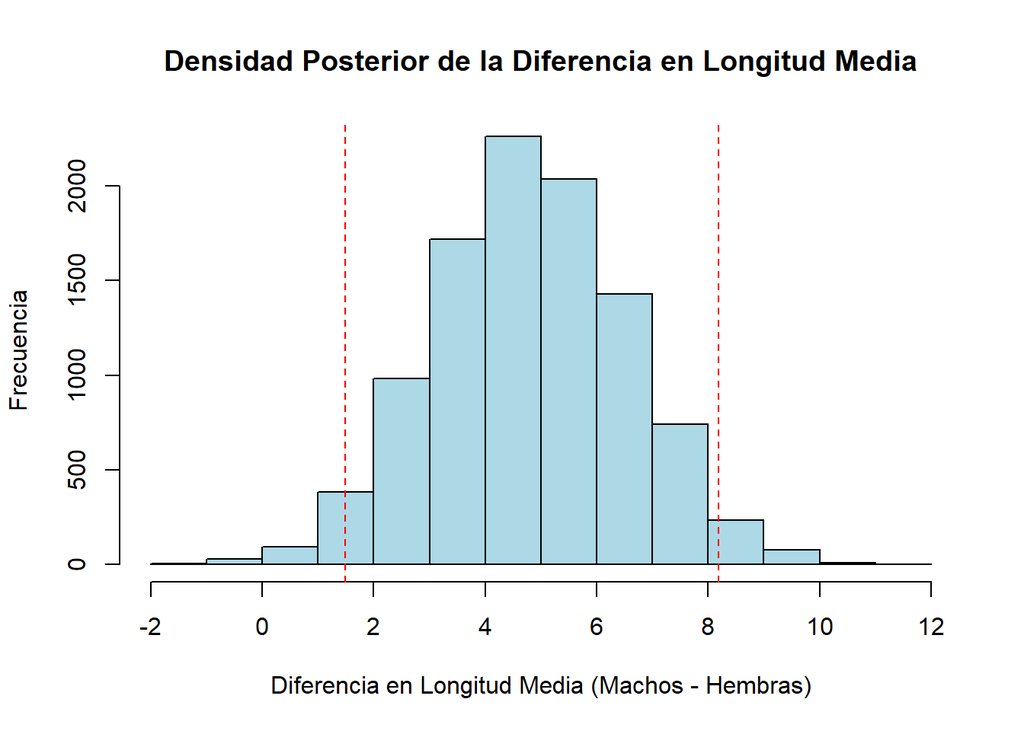

```r
# Datos
machos <- c(120, 107, 110, 116, 114, 111, 113, 117, 114, 112)
hembras <- c(110, 111, 107, 108, 110, 105, 107, 106, 111, 111)

# Parámetros iniciales
mu_m <- mean(machos)
mu_h <- mean(hembras)
sigma <- sd(c(machos, hembras))
iteraciones <- 10000

# Almacenar resultados
dif_long <- numeric(iteraciones)

# Simulación con muestreo de Gibbs
set.seed(123)
for (i in 1:iteraciones) {
  # Actualizar mu_machos condicional a otros parámetros y datos
  mu_m <- rnorm(1, mean = mean(machos), sd = sigma/sqrt(length(machos)))

  # Actualizar mu_hembras condicional a otros parámetros y datos
  mu_h <- rnorm(1, mean = mean(hembras), sd = sigma/sqrt(length(hembras)))

  # Calcular la diferencia de medias y almacenar en el vector resultado
  dif_long[i] <- mu_m - mu_h
}

# Visualización de la densidad posterior
hist(dif_long, col = "lightblue", main = "Densidad Posterior de la Diferencia en Longitud Media",
     xlab = "Diferencia en Longitud Media (Machos - Hembras)", ylab = "Frecuencia")

# Percentil 2.5 y 97.5 para intervalo de credibilidad del 95%
quantiles <- quantile(dif_long, c(0.025, 0.975))
abline(v = quantiles, col = "red", lty = 2)
```

```r
# Sumario estadístico
cat("Intervalo de credibilidad al 95%: [", round(quantiles[1], 2), ",", round(quantiles[2], 2), "]\n")
```

```
## Intervalo de credibilidad al 95%: [ 1.48 , 8.19 ]
```

> ¿Hay suficiente evidencia para concluir que los machos tienen una longitud promedio mayor que las hembras?

> Si, dado que los resultados de las simulaciones de las diferencias entre la medida de la mandibula de los machos vs la de las hembras, queda en un rango positivo [1.48,8.19].

## 8. Estimando los parámetros de una densidad Poisson/Gamma.

> Supongamos que $y_1, . . . , y_n$ es una muestra aleatoria de una densidad Poisson/Gamma:
> $$f(y|a,b)=\frac{\Gamma(y+a)}{\Gamma(a)y!}
> \frac{b^a}{(b+1)^{y+a}}$$
> donde $a≥0, b≥0$. Esta densidad es un modelo apropiado para conteos que muestran más dispersión que la que predice un modelo Poisson. Supongamos que $(a,b)$ tiene asignada la inicial no informativa proporcional a $1/(ab)^2$. Si transformamos a los parámetros $\theta_1=log(a)$ y $\theta_2=log(b)$, la densidad posterior es
> proporcional a
> $$g(\theta_1,\theta_2)\propto\frac{1}{ab}\prod_{i=1}^{n}\frac{\Gamma(y_i+a)}{\Gamma(a)y_i!}
> \frac{b^a}{(b+1)^{y_i+a}}$$
> donde $a=exp(\theta_1)$ y $b=exp(\theta_2)$ Usa este marco para modelar los datos obtenidos por Gilchrist (1984), en los que una serie de 33 trampas de insectos fueron puestas sobre varias dunas de arena y se registra el número de diferentes insectos atrapados sobre un tiempo fijo. El número de insectos en las trampas se muestran a continuación:

| 2 | 5 | 0 | 2 | 3 | 1 | 3 | 4 | 3 | 0 | 3 |
| --- | --- | --- | --- | --- | --- | --- | --- | --- | --- | --- |
| 2 | 1 | 1 | 0 | 6 | 0 | 0 | 3 | 0 | 1 | 1 |
| 5 | 0 | 1 | 2 | 0 | 0 | 2 | 1 | 1 | 1 | 0 |

> Calculando la densidad posterior sobre una retícula, simular 1000 extracciones de la densidad conjunta posterior de $(\theta_1, \theta_2)$. De la muestra simulada, encontrar intervalos estimados de 90% para los parámetros $a$ y $b$.

```r
# Datos observados
y <- c(2, 5, 0, 2, 3, 1, 3, 4, 3, 0, 3, 2, 1, 1, 0, 6, 0, 0, 3, 0, 1, 1, 5, 0, 1, 2, 0, 0, 2, 1, 1, 1, 0)

# Función de densidad posterior
dpost_PoisGamm <- function(theta1, theta2, y) {
  a <- exp(theta1)
  b <- exp(theta2)
  n <- length(y)

  # Logaritmo de la función de densidad posterior
  log_post <- sum(lgamma(y + a) - lgamma(a) - lgamma(y + 1) + a * log(b) - (y + a) * log(b + 1))

  # Normalización (logaritmo)
  log_norm <- - n * log(a * b)

  # Logaritmo de la densidad posterior no normalizada
  log_nonorm_post <- log_post + log_norm

  return(log_nonorm_post)
}

# Grid para thetas
v_theta1 <- seq(-2, 2, 0.01)
v_theta2 <- seq(-2, 2, 0.01)

# Se obtienen las posteriores de theta
vero_thetas <- sapply(v_theta1, function(theta1) {
  sapply(v_theta2, function(theta2) {
    sum(dpost_PoisGamm(theta1, theta2, y)) - (theta1 + theta2) })
  }) |> apply(c(1, 2), sum)


# Simulación de 1000 veces la densidad conjunta posterior
set.seed(123)
muestras_sim <- replicate(1000, {
  theta1_m <- sample(v_theta1, 1, prob = colSums(exp(vero_thetas)))
  theta2_m <- sample(v_theta2, 1, prob = rowSums(exp(vero_thetas)))
  c(exp(theta1_m),exp(theta2_m))
})

# Intervalos estimados del 90%
quantiles <- apply(muestras_sim, 1, quantile, c(0.05, 0.95), na.rm = TRUE)

# Imprimir resultados
cat("Intervalo estimado del 90% para a:", round(quantiles[1, 1], 4), "-", round(quantiles[2, 1], 4), "\n")
```

```
## Intervalo estimado del 90% para a: 0.1353 - 0.1588
```

```r
cat("Intervalo estimado del 90% para b:", round(quantiles[1, 2], 4), "-", round(quantiles[2, 2], 4), "\n")
```

```
## Intervalo estimado del 90% para b: 0.1353 - 0.1451
```